# R For Data Science Book Club – Ch. 1 & 2

7/31/2020

## Welcome!

[figure not shown]

We’ll be covering a different chapter of [R for Data Science](https://r4ds.had.co.nz/index.html) by Hadley Wickham & Garrett Grolemund every Friday at 8 p.m. Eastern/5 p.m. Pacific.

Sessions will be recorded if you can’t make it live every week.

Are you up for presenting one week? Let me know!

## What we’ll learn

> "You’ll learn how to get your data into R, get it into the most useful structure, transform it, visualize it and model it.

…

> “Just as a chemist learns to clean test tubes and stock a lab, you’ll learn how to clean data and draw plots — and many other things besides.”

*— Wickham & Grolemund, welcome page*

## The Data Science Project Model

[figure not shown]

*– Wickham & Grolemund, Ch. 1.1*

**Import** – Getting you data into R

## The Data Science Project Model

[figure not shown]

*– Wickham & Grolemund, Ch. 1.1*

**Tidy** – Storing your data in a consistent form

## The Data Science Project Model

[figure not shown]

*– Wickham & Grolemund, Ch. 1.1*

**Transform** – Narrowing in on observations of interest and creating new variables from ones already existing

## The Data Science Project Model

[figure not shown]

*– Wickham & Grolemund, Ch. 1.1*

**Visualize** – Visually representing your data

## The Data Science Project Model

[figure not shown]

*– Wickham & Grolemund, Ch. 1.1*

**Model** - Using your data to answer the question at hand

## The Data Science Project Model

[figure not shown]

*– Wickham & Grolemund, Ch. 1.1*

**Communicate** - Relaying your findings to others

> “You don’t need to be an expert programmer to be a data scientist, but becoming a better programmer allows you to automate common tasks, and solve new problems with greater ease.”

*– Wickham & Grolemund, Ch. 1.1*

## The 80-20 Rule

> “You can tackle about 80% of every project using the tools that you’ll learn in this book, but you’ll need other tools to tackle the remaining 20%.”

*– Wickham & Grolemund, Ch. 1.1*

That final 20% will vary by project, the data you’re exploring and the questions you’re hoping to answer.

## A Wise Word from the Authors

> “While it’s tempting to skip the exercises, there’s no better way to learn than practicing on real problems.”

Fortunately, there’s someone who’s run through this book before and created a sort of [answer key](https://jrnold.github.io/r4ds-exercise-solutions/).

(But seriously … you’ll learn more if you at least try to solve it on your own first)

## Run into trouble? You’re not alone

Confused by an error you received?

Try Googling the error message.

Other places to look for help:

[Stack Overflow](https://stackoverflow.com/)

[Community.Rstudio](https://community.rstudio.com/) (Imagine a less-grouchy Stack Overflow)

R4DS Slack

## What You Need for this Book Club

1. [Install R](https://cloud.r-project.org/)
2. [Install RStudio](https://rstudio.com/products/rstudio/download/)
3. Open RStudio and install the Tidyverse package by typing or pasting the following in the console (bottom-left box)

`install.packages("tidyverse")`

1. Install these other packages the book uses as examples by typing or pasting the following in the console

`install.packages(c("nycflights13", "gapminder", "Lahman"))`

## See you next week!

We’ll be tackling **Data Visualization**

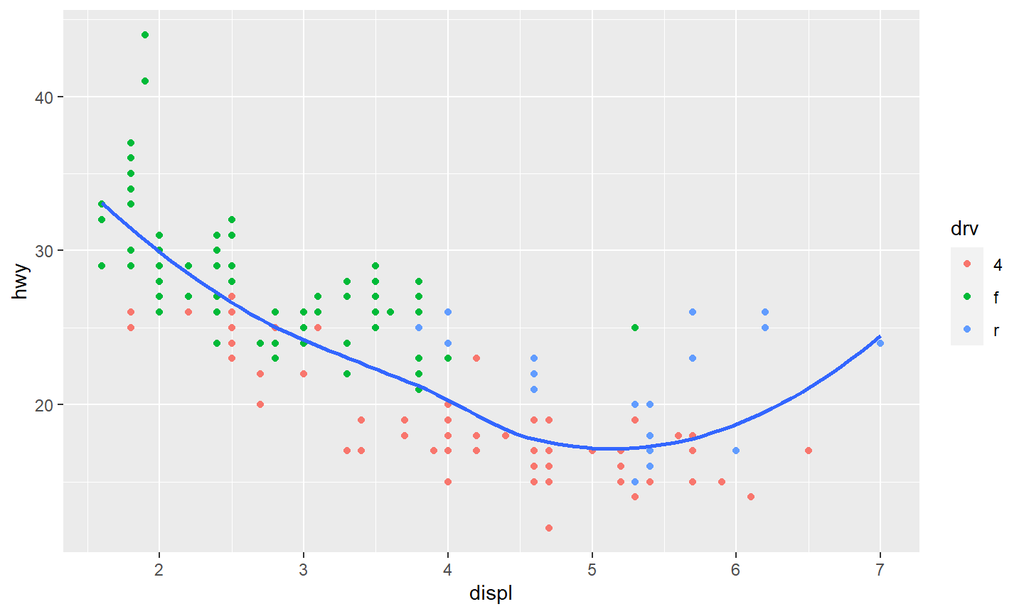